# TP-01 Javier Duque

## 1. Preparacion de los datos (I)

Comenzamos leyendo el dataframe y se muestra la estructura de las variables, el tipo de datos

```r
#Se cargan las librerias a usar
library(readr)
library(tidyverse)
library(GGally)
```

```r
#Se lee el dataset y se procede a revisar la estructura de los datos
ar_properties <- read_csv("~/Maestria DM/Enfoque estadistico del aprendizaje/EEA2019JD/EEA2019/TP/ar_properties.csv")
glimpse(ar_properties)
```

```
Observations: 388,891
Variables: 24
$ id              <chr> "S0we3z3V2JpHUJreqQ2t/w==", "kMxcmAS8NvrynGBVbMOEaQ==", "Ce3ojF+ZTOkB8d+LI9d...
$ ad_type         <chr> "Propiedad", "Propiedad", "Propiedad", "Propiedad", "Propiedad", "Propiedad"...
$ start_date      <date> 2019-04-14, 2019-04-14, 2019-04-14, 2019-04-14, 2019-04-14, 2019-04-14, 201...
$ end_date        <date> 2019-06-14, 2019-04-16, 9999-12-31, 9999-12-31, 2019-07-09, 2019-08-08, 201...
$ created_on      <date> 2019-04-14, 2019-04-14, 2019-04-14, 2019-04-14, 2019-04-14, 2019-04-14, 201...
$ lat             <dbl> -34.94331, -34.63181, NA, -34.65471, -34.65495, -32.93547, -34.65183, -34.91...
$ lon             <dbl> -54.92966, -58.42060, NA, -58.79089, -58.78712, -60.68398, -58.65912, -54.84...
$ l1              <chr> "Uruguay", "Argentina", "Argentina", "Argentina", "Argentina", "Argentina", ...
$ l2              <chr> "Maldonado", "Capital Federal", "Bs.As. G.B.A. Zona Norte", "Bs.As. G.B.A. Z...
$ l3              <chr> "Punta del Este", "Boedo", NA, "Moreno", "Moreno", "Rosario", "Ituzaingó", "...
$ l4              <chr> NA, NA, NA, "Moreno", "Moreno", NA, "Ituzaingó", NA, NA, NA, NA, NA, NA, NA,...
$ l5              <chr> NA, NA, NA, NA, NA, NA, NA, NA, NA, NA, NA, NA, NA, NA, NA, NA, NA, NA, NA, ...
$ l6              <lgl> NA, NA, NA, NA, NA, NA, NA, NA, NA, NA, NA, NA, NA, NA, NA, NA, NA, NA, NA, ...
$ rooms           <dbl> 2, NA, 2, 2, 2, 4, NA, 6, NA, NA, NA, NA, NA, NA, NA, NA, NA, NA, NA, NA, 1,...
$ bedrooms        <dbl> NA, NA, NA, NA, NA, NA, NA, NA, NA, NA, NA, NA, NA, NA, NA, NA, NA, NA, NA, ...
$ bathrooms       <dbl> 1, NA, 1, 2, 3, 1, 3, 3, NA, NA, NA, NA, NA, NA, NA, NA, NA, NA, 1, NA, 1, 1...
$ surface_total   <dbl> 45, NA, 200, 460, 660, NA, 70, NA, 1300, 405, 352, 373, 360, 1325, 250, 8014...
$ surface_covered <dbl> 40, NA, NA, 100, 148, 89, 122, NA, NA, NA, NA, NA, NA, 2, NA, NA, NA, NA, 54...
$ price           <dbl> 13000, 0, NA, NA, NA, NA, NA, NA, 0, NA, 0, NA, NA, NA, NA, NA, 0, 0, 0, NA,...
$ currency        <chr> "UYU", NA, NA, NA, NA, NA, NA, NA, NA, NA, NA, NA, NA, NA, NA, NA, NA, NA, N...
$ price_period    <chr> "Mensual", "Mensual", NA, "Mensual", "Mensual", "Mensual", "Mensual", "Mensu...
$ title           <chr> "Departamento - Roosevelt", "PH - Boedo", "Ituzaingo  1100 - $ 1 - Casa Alqu...
$ property_type   <chr> "Departamento", "PH", "Casa", "Casa", "Casa", "Casa", "Casa", "Casa", "Lote"...
$ operation_type  <chr> "Alquiler", "Venta", "Alquiler", "Venta", "Venta", "Venta", "Venta", "Alquil...
```

Se realiza un filtro para quedarse con los registros:

1. Pertenecen a Argentina y Capital Federal
2. Cuyo precio esta en dolares (USD)
3. El tipo de propiedad sea: Departamento, PH o Casa
4. El tipo de operacion sea Venta

Se seleccionan las variables de interes para el analisis:

id, l3, rooms, bedrooms, bathrooms, surface_total, surface_covered, price y property_type

```r
#Se realiza un filtrado de las variables que se desean obtener y luego se seleccionan las variables de interes
dataframe <- ar_properties %>%
  filter(l1=="Argentina",
         l2=="Capital Federal",
         currency=="USD",
         property_type %in% c("Departamento","PH", "Casa"),
         operation_type=="Venta")%>%
  select("id","l3","rooms","bedrooms","bathrooms","surface_total","surface_covered", "price","property_type")

dataframe
```

| id | l3 | rooms | bedrooms | bathrooms | surface_total | surface_covered | price | property_type |
| --- | --- | --- | --- | --- | --- | --- | --- | --- |
| oyj+f764ALCYodIqBvWAww== | Barracas | NA | NA | NA | 300 | 180 | 320000 | PH |
| HdjpKrqdwYfH9YU1DKjltg== | Boedo | 6 | NA | 2 | 178 | 240 | 500000 | Casa |
| YwWE3rTb2+gmsBwjUHmAPQ== | Palermo | NA | NA | 2 | 240 | 157 | 350000 | Casa |
| 6AxnSWOhbIU8TUCqb+paBg== | Belgrano | 3 | NA | 4 | 157 | NA | 470000 | Casa |
| U4fk+co3Rd8JDMot0pQI6Q== | Versalles | NA | NA | 1 | 140 | 110 | 155000 | Casa |
| AfdcsqUSelai1ofCAq2B0Q== | Velez Sarsfield | 3 | NA | 2 | 95 | 69 | 199900 | Casa |
| ESzybdH7YU2uIU1/kHtRGw== | Nuñez | 1 | NA | 1 | 44 | 38 | 147000 | Departamento |
| r22OfzZ3kXooSPoE5HMuZQ== | Almagro | 1 | NA | 1 | 40 | 37 | 92294 | Departamento |
| atZQXVtyfG7+OiX6gYY3lA== | Almagro | 1 | NA | 1 | 49 | 44 | 115000 | Departamento |
| R7IsTtVsxPCiRbIHMaWGxA== | Almagro | 1 | NA | 1 | 40 | 37 | 77000 | Departamento |

[output cut: 990 more lines]

## 2. Analisis exploratorios (I)

Obtener la cantidad de valores unicos y de valores faltantes (NAs) para cada una de estas variables

#### Se muestra el conteo de valores unicos por cada variable

```r
# Se cuentan la cantidad de valores unicos por cada variable
map(dataframe,~n_distinct(.))
```

```
$id
[1] 61905

$l3
[1] 58

$rooms
[1] 24

$bedrooms
[1] 25

$bathrooms
[1] 15

$surface_total
[1] 671

$surface_covered
[1] 573

$price
[1] 4095

$property_type
[1] 3
```

En la tabla anterior se puede dar por descartada la variable “id” ya que esta por ser el identificador unico debe tener un unico valor por registro, en cuanto la variable de superficie se ve una diversidad de valores diferentes lo que es algo que puede deberse a la forma de la toma de los datos y la precision de la medicion. En cuanto a la variable “property_type” deberia salir solo tres valores puesto que fue el filtro aplicado previamente

#### Se muestra el conteo de valores faltantes por cada variable

```r
# Se cuentan la cantidad de valores faltantes por cada variable
map(dataframe, ~sum(is.na(.)))
```

```
$id
[1] 0

$l3
[1] 355

$rooms
[1] 5314

$bedrooms
[1] 25298

$bathrooms
[1] 3196

$surface_total
[1] 3671

$surface_covered
[1] 2975

$price
[1] 0

$property_type
[1] 0
```

Las variable de “bedrooms” presenta un alto valor de faltantes, por lo que parece que es una variable que no es muy tomada en cuenta para definir un valor real de la propiedad o se entiende que puede ser una variable complementaria de la “rooms”

La variable de “price” no presentan faltantes lo cual es idoneo para realizar un analisis de esta variable a futuro.

#### Se realiza una matriz de correlacion entre las variables

```r
# Se realiza una matriz de correlacion, se presentan como una matriz diagonal puesto que el resultado es una matriz simetrica
datacorrelate <- dataframe %>%
  select("rooms","bedrooms","bathrooms","surface_total","surface_covered", "price")%>%
  cor(.,use="pairwise.complete.obs")

datacorrelate
```

```
                     rooms   bedrooms  bathrooms surface_total surface_covered      price
rooms           1.00000000 0.92382161 0.62574631    0.08169819      0.09199855 0.30418750
bedrooms        0.92382161 1.00000000 0.62667805    0.07892981      0.08435479 0.34137037
bathrooms       0.62574631 0.62667805 1.00000000    0.08607046      0.09633800 0.42063819
surface_total   0.08169819 0.07892981 0.08607046    1.00000000      0.69441844 0.07664240
surface_covered 0.09199855 0.08435479 0.09633800    0.69441844      1.00000000 0.09236313
price           0.30418750 0.34137037 0.42063819    0.07664240      0.09236313 1.00000000
```

## 3. Preparacion de los datos (II)

En el punto 2 deberian haber encontrado que la variable bedrooms presenta una alta proporción de valores faltantes y que presenta una fuerte correlacion con la variable rooms.

#### Se procede a eliminar la variable “Bedrooms”

#### Luego se procede a eliminar todos los registros que contengan valores faltantes

```r
# Se elimina la variable bedrooms
datacomplete <- dataframe %>%
  select(-c("bedrooms"))%>%
  na.omit(.)        #Se eliminan los registros que contienen valores faltantes

datacomplete
```

| id | l3 | rooms | bathrooms | surface_total | surface_covered | price | property_type |
| --- | --- | --- | --- | --- | --- | --- | --- |
| HdjpKrqdwYfH9YU1DKjltg== | Boedo | 6 | 2 | 178 | 240 | 500000 | Casa |
| AfdcsqUSelai1ofCAq2B0Q== | Velez Sarsfield | 3 | 2 | 95 | 69 | 199900 | Casa |
| ESzybdH7YU2uIU1/kHtRGw== | Nuñez | 1 | 1 | 44 | 38 | 147000 | Departamento |
| r22OfzZ3kXooSPoE5HMuZQ== | Almagro | 1 | 1 | 40 | 37 | 92294 | Departamento |
| atZQXVtyfG7+OiX6gYY3lA== | Almagro | 1 | 1 | 49 | 44 | 115000 | Departamento |
| R7IsTtVsxPCiRbIHMaWGxA== | Almagro | 1 | 1 | 40 | 37 | 77000 | Departamento |
| Tur/v/qE41UBT83NM/bI7w== | Almagro | 1 | 1 | 40 | 37 | 88900 | Departamento |
| PNtNl6sWjHEyRPQAeRAIgw== | Almagro | 1 | 1 | 40 | 37 | 88798 | Departamento |
| Lhg4dNG9VmPbHt0Swy2ATA== | Almagro | 1 | 1 | 49 | 44 | 110975 | Departamento |
| MFngc+8f1sFriO+lteUuZw== | Almagro | 1 | 1 | 40 | 37 | 92943 | Departamento |

[output cut: 990 more lines]

## 4. Analisis exploratorios (II)

#### Obtener estadisticas descriptivas para la variable precio (cuartiles, promedio, minimo y maximo) y realizar un histograma de la variable

```r
# Se obtienen las caracteristicas descriptivas
datacomplete%>%
  summarise(mean(price),
            quantile(price,0.25),
            quantile(price,0.75),
            min(price),
            max(price))
```

| mean(price) | quantile(price, 0.25) | quantile(price, 0.75) | min(price) | max(price) |
| --- | --- | --- | --- | --- |
| 251577.2 | 119000 | 270000 | 6000 | 6e+06 |

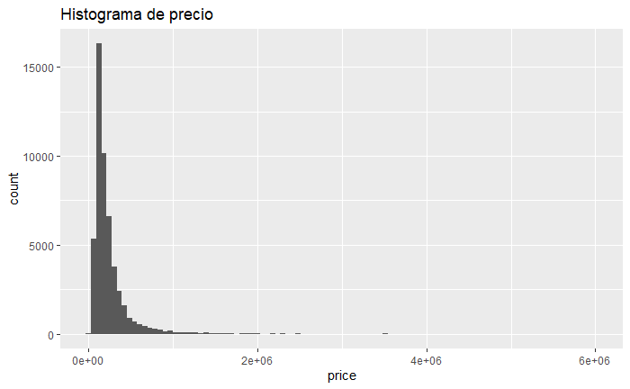

```r
#Se realiza el histograma de la varaible precio
ggplot(datacomplete,aes(price)) +
  geom_histogram(bins = 100) +
  labs(title = "Histograma de precio")
```

El histograma presenta unos outliers por lo que hace que se vea una mayor concentracion de datos en una franja y pocos sobre los valores altos. Se puede ver que tiene una distribucion sesgada.

#### Obtener estadisticas descriptivas para la variable precio (cuartiles, promedio, minimo y maximo) por cada tipo de propiedad.

```r
# Se obtienen las caracteristicas descriptivas de la variable precio por tipo de propiedad
datacomplete%>%
  group_by(factor(property_type))%>%
  summarise(mean(price),
            quantile(price,0.25),
            quantile(price,0.75),
            min(price),
            max(price))
```

| factor(property_type) | mean(price) | quantile(price, 0.25) | quantile(price, 0.75) | min(price) | max(price) |
| --- | --- | --- | --- | --- | --- |
| Casa | 434188.8 | 235000 | 490000 | 20000 | 5000000 |
| Departamento | 246855.7 | 115000 | 260000 | 6000 | 6000000 |
| PH | 218747.4 | 137000 | 270000 | 32000 | 1500000 |

#### Realizar un grafico de boxplot de la variable precio por tipo de propiedad

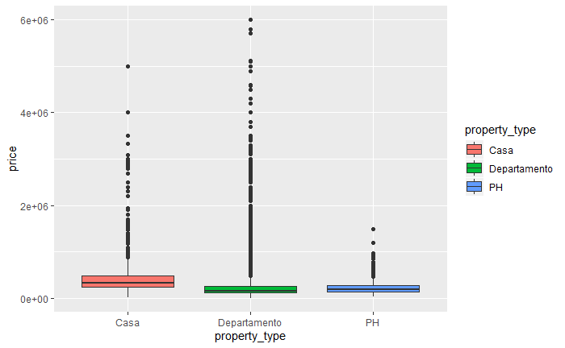

```r
# Se realiza un Boxplot de la variable precio por el tipo de propiedad
ggplot(datacomplete, aes(property_type,price, fill = property_type))+
  geom_boxplot()
```

Se puede evidenciar que hay registros con valores extremos, esto no se debe a la toma del dato sino a la distribucion del mismo, puesto que al ser precio de una propiedad y no tener todos los valores que estan presentes a la hora de definir un valor estos podrian verse mas elevados, por ser propiedades de mas tamaño, menos antiguedad, mayores comodidades, mejor ubicacion.

#### Realizar un correlagrama usando GGAlly

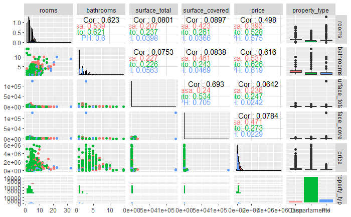

```r
#Se realiza un correlograma de las variables, se eliminan "id" y "l3" ya que tienen demasiados valores unicos
datagraph <- datacomplete%>%
  select(-c("id","l3"))
ggpairs(datagraph,  mapping = aes(color = property_type))
```

Al analizar el grafico de correlacion entre las variables, se ve un poco extraño como la variable precio y las variables asociadas a la superficie de la propiedad poseen una correlacion baja, aunque en la realidad esta es una caracteristica que se tiene en cuenta a la hora de definir un precio para la propiedad. En cuanto a la correlacion entre precio y las variables bathrooms y rooms presentan la correlacion mas alta lo que si seria algo logico.

## 5. Outliers

#### Eliminar los outliers de la variable precio

```r
#calculamos el IRQ de acuerdo a cada tipo de propiedad
#para propiedad tipo Casa
datoscasa <- datacomplete %>%
  filter(property_type=='Casa')

valorcuantiles_casa <- quantile(datoscasa$price, c(0.25,0.75))
IRQ_Casa <- valorcuantiles_casa[2] - valorcuantiles_casa[1]

#para propiedad tipo Departamento
datosDepartamento <- datacomplete %>%
  filter(property_type=='Departamento')
valorcuantiles_departamento <- quantile(datosDepartamento$price, c(0.25,0.75))
IRQ_Departamento <- valorcuantiles_departamento[2] - valorcuantiles_departamento[1]

#para propiedad tipo Departamento
datosPH <- datacomplete %>%
  filter(property_type=='PH')
valorcuantiles_PH <- quantile(datosPH$price, c(0.25,0.75))
IRQ_PH <- valorcuantiles_PH[2] - valorcuantiles_PH[1]


#ahora con este valores hacemos el filtro en el dataset global
data_sinoutliers <- datacomplete %>%
  filter(
    (property_type=='Casa' & price >= valorcuantiles_casa[1]-IRQ_Casa*1.5 & price <= valorcuantiles_casa[2]+IRQ_Casa+1.5)|
    (property_type=='Departamento'& price >= valorcuantiles_departamento[1]-IRQ_Departamento*1.5 & price <= valorcuantiles_departamento[2]+IRQ_Departamento*1.5)|
    (property_type=='PH' & price >= valorcuantiles_PH[1]-IRQ_PH*1.5 & price <= valorcuantiles_PH[2]+IRQ_PH*1.5))

glimpse(data_sinoutliers)
```

```
Observations: 46,865
Variables: 8
$ id              <chr> "HdjpKrqdwYfH9YU1DKjltg==", "AfdcsqUSelai1ofCAq2B0Q==", "ESzybdH7YU2uIU1/kHt...
$ l3              <chr> "Boedo", "Velez Sarsfield", "Nuñez", "Almagro", "Almagro", "Almagro", "Almag...
$ rooms           <dbl> 6, 3, 1, 1, 1, 1, 1, 1, 1, 1, 1, 1, 1, 1, 1, 1, 3, 1, 1, 2, 1, 1, 1, 1, 1, 1...
$ bathrooms       <dbl> 2, 2, 1, 1, 1, 1, 1, 1, 1, 1, 1, 1, 1, 1, 1, 1, 2, 1, 1, 1, 1, 1, 1, 1, 1, 1...
$ surface_total   <dbl> 178, 95, 44, 40, 49, 40, 40, 40, 49, 40, 23, 40, 40, 32, 40, 36, 90, 45, 54,...
$ surface_covered <dbl> 240, 69, 38, 37, 44, 37, 37, 37, 44, 37, 23, 37, 37, 30, 34, 33, 90, 35, 48,...
$ price           <dbl> 500000, 199900, 147000, 92294, 115000, 77000, 88900, 88798, 110975, 92943, 6...
$ property_type   <chr> "Casa", "Casa", "Departamento", "Departamento", "Departamento", "Departament...
```

## 6. Analisis exploratorios (III)

Repetir los 4 análisis exploratorios realizados en el punto 4 y realizar unos breves comentarios sobre los cambios que encontraron

#### Obtener estadisticas descriptivas para la variable precio (cuartiles, promedio, minimo y maximo) y realizar un histograma de la variable

```r
# Se obtienen las caracteristicas descriptivas
data_sinoutliers%>%
  summarise(mean(price),
            quantile(price,0.25),
            quantile(price,0.75),
            min(price),
            max(price))
```

| mean(price) | quantile(price, 0.25) | quantile(price, 0.75) | min(price) | max(price) |
| --- | --- | --- | --- | --- |
| 187667.2 | 115000 | 240000 | 6000 | 745000 |

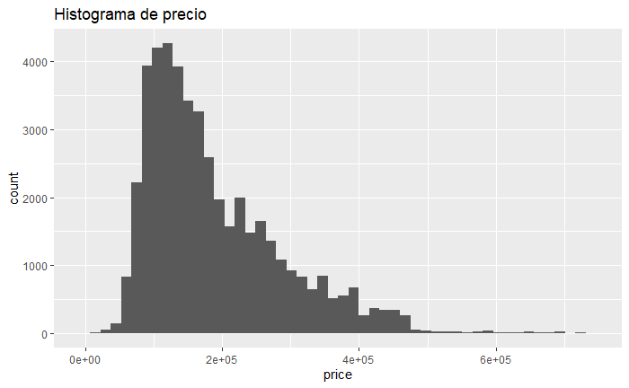

```r
#Se realiza el histograma de la varaible precio
ggplot(data_sinoutliers,aes(price)) +
  geom_histogram(bins = 50) +
  labs(title = "Histograma de precio")
```

#### Obtener estadisticas descriptivas para la variable precio (cuartiles, promedio, minimo y maximo) por cada tipo de propiedad.

```r
# Se obtienen las caracteristicas descriptivas de la variable precio por tipo de propiedad
data_sinoutliers%>%
  group_by(factor(property_type))%>%
  summarise(mean(price),
            quantile(price,0.25),
            quantile(price,0.75),
            min(price),
            max(price))
```

| factor(property_type) | mean(price) | quantile(price, 0.25) | quantile(price, 0.75) | min(price) | max(price) |
| --- | --- | --- | --- | --- | --- |
| Casa | 333698.4 | 220000 | 428000 | 20000 | 745000 |
| Departamento | 178809.4 | 110000 | 229000 | 6000 | 477285 |
| PH | 207077.6 | 135000 | 269000 | 32000 | 468000 |

#### Realizar un grafico de boxplot de la variable precio por tipo de propiedad

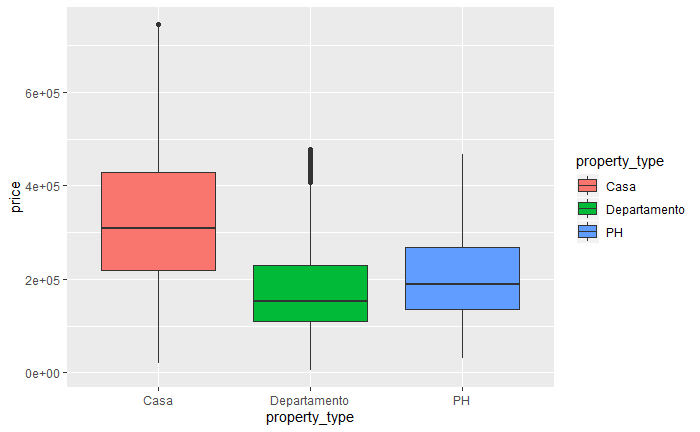

```r
# Se obtienen las caracteristicas descriptivas de la variable precio por tipo de propiedad
ggplot(data_sinoutliers, aes(property_type,price, fill = property_type))+
  geom_boxplot()
```

Se puede ver que los valores promedio entre los tipo de propiedad PH y departamento tienen alguna similitud, en cambio en casa es un poco mas alto, esto se puede deber a que normalmente las casas presentan una superficie y una cantidad de cuartos mas grande. Las distribuciones del tipo PH y departamento presentan valores similares en cuanto a su varianza y sus valores maximos.

#### Realizar un correlagrama usando GGAlly

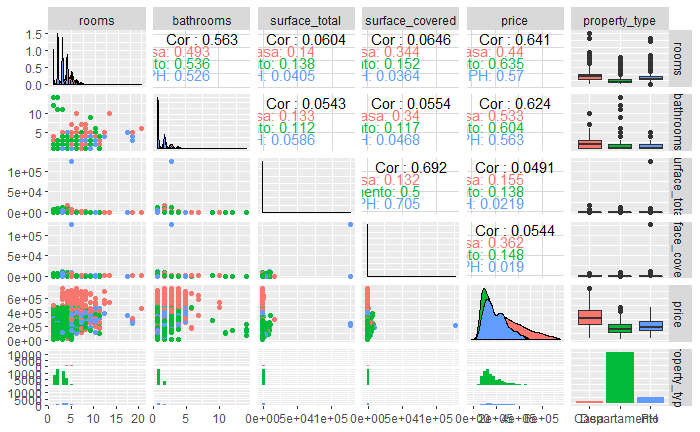

```r
datagraph <- data_sinoutliers%>%
  select(-c("id","l3"))
ggpairs(datagraph,  mapping = aes(color = property_type))
```

Al analizar el grafico de correlacion entre las variables, se mantiene la relacion existente entre la variable precio y las variables asociadas a la superficie de la propiedad con una correlacion baja. En cuanto a la correlacion entre precio y las variables bathrooms y rooms presentan una correlacion mas alta con respecto a la medicion realizada antes de la eliminacion de los outliers.

## 7. Modelo lineal

Realizar un modelo lineal simple para explicar el precio en función de las habitaciones (rooms) y otro modelo que explique el precio en función de la superficie total (surface_total)

#### Modelo lineal simple del precio en funcion de las habitaciones

```r
# Se realiza el modelo de regresion lineal simple
rl_model<-lm(price ~ rooms, data = data_sinoutliers)
summary(rl_model)
```

```
Call:
lm(formula = price ~ rooms, data = data_sinoutliers)

Residuals:
    Min      1Q  Median      3Q     Max
-724704  -46535  -10952   33048  533948

Coefficients:
            Estimate Std. Error t value Pr(>|t|)
(Intercept)  54401.6      814.8   66.77   <2e-16 ***
rooms        50516.8      279.1  180.97   <2e-16 ***
---
Signif. codes:  0 ‘***’ 0.001 ‘**’ 0.01 ‘*’ 0.05 ‘.’ 0.1 ‘ ’ 1

Residual standard error: 75490 on 46863 degrees of freedom
Multiple R-squared:  0.4114,    Adjusted R-squared:  0.4113
F-statistic: 3.275e+04 on 1 and 46863 DF,  p-value: < 2.2e-16
```

El modelo seria el siguiente: Price = 54401.6 + 50516.8 * (Rooms)

Lo que nos da a entender es que en el caso de tener 0 habitaciones la propiedad lo cual no tiene mucho sentido este tendria un valor de 54401.6. En cuanto al valor de 50516.8 es el valor de la pendiente, por lo que por cada cambio de una habitacion el valor promedio de la propiedad estaria incrementando en 50516.8

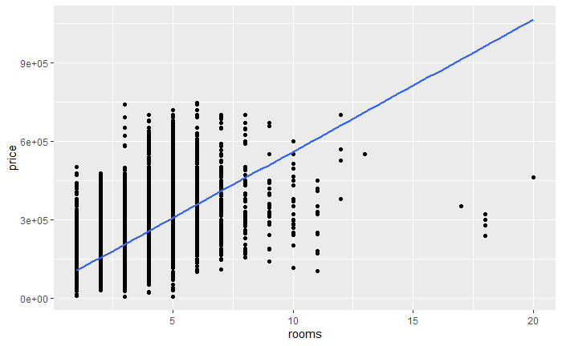

```r
#Graficamos el modelo de regresion obtenido
ggplot(data_sinoutliers, aes(x = rooms, y = price)) +
  geom_point(aes(y = price)) +
  geom_smooth(method = lm, se = FALSE)
```

#### Modelo lineal simple del precio en funcion de la superficie total (surface_total)

```r
# Se realiza el modelo de regresion lineal simple
rl_model<-lm(price ~ surface_total, data = data_sinoutliers)
summary(rl_model)
```

```
Call:
lm(formula = price ~ surface_total, data = data_sinoutliers)

Residuals:
    Min      1Q  Median      3Q     Max
-690014  -72472  -27697   52280  555452

Coefficients:
               Estimate Std. Error t value Pr(>|t|)
(Intercept)   1.872e+05  4.565e+02  409.98   <2e-16 ***
surface_total 5.694e+00  5.346e-01   10.65   <2e-16 ***
---
Signif. codes:  0 ‘***’ 0.001 ‘**’ 0.01 ‘*’ 0.05 ‘.’ 0.1 ‘ ’ 1

Residual standard error: 98280 on 46863 degrees of freedom
Multiple R-squared:  0.002415,  Adjusted R-squared:  0.002394
F-statistic: 113.5 on 1 and 46863 DF,  p-value: < 2.2e-16
```

El modelo seria el siguiente: Price = 187200 + 5.694 * (Surface_total)

Lo que nos da a entender es que el valor base que tienen todas las propiedades serian de 187200, esto es por le valor del cruce por el eje, es decir cuando no tiene un area la propiedad. En cuanto al valor de 5.694 es el valor de la pendiente, por lo que por cada cambio de una unidad de medida de la superficie total el valor promedio de la propiedad estaria incrementando en 5.694

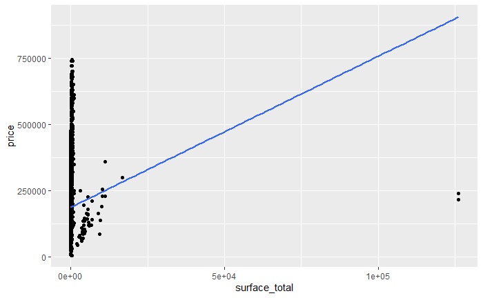

```r
#Graficamos el modelo de regresion obtenido
ggplot(data_sinoutliers, aes(x = surface_total, y = price)) +
  geom_point(aes(y = price)) +
  geom_smooth(method = lm, se = FALSE)
```

#### ¿Cuál modelo usarían para predecir el precio? ¿Por qué?

De acuerdo a los resultados obtenidos, el modelo que tendria un menor error en los valores seria el de la prediccion del precio de las propiedades de acuerdo a la cantidad de habitaciones, adicional el valor de R^2 es mayor en el modelo por lo que es mejor la prediccion.